Universidad El Bosque

Diseño de Experimentos

Sesión 2 de 2 · 90 min

# Diseños en bloques completos al azar

Cuánto se gana bloqueando, cómo se compara y qué se revisa

Eficiencia relativaComparaciones y potenciaNo aditividad de TukeyDato faltanteBloque aleatorioValidación por grupos

**Javier Mauricio Sierra**

Universidad El Bosque

Diseño de Experimentos

Capítulo 5 · Diseños en bloques completos al azar

Eficiencia relativa

Comparaciones y número de bloques

Diagnóstico y no aditividad

Cuando falta un dato

El bloque como factor aleatorio

Ciencia de datos

Cierre y práctica

Hoja de ruta

## Lo que vamos a construir hoy

Objetivo de la sesión

Medir cuánto rinde un bloque con la eficiencia relativa, llevar al DBCA las comparaciones y la potencia, revisar la aditividad con la prueba de Tukey, y reconocer el dato faltante, el bloque aleatorio y el bloqueo fuera del laboratorio.

Eficiencia relativaComparaciones y potenciaNo aditividad de TukeyDato faltanteBloque aleatorioValidación por grupos

2 / 37

Universidad El Bosque

Diseño de Experimentos

Capítulo 5 · Diseños en bloques completos al azar

Eficiencia relativa

Comparaciones y número de bloques

Diagnóstico y no aditividad

Cuando falta un dato

El bloque como factor aleatorio

Ciencia de datos

Cierre y práctica

01

## Eficiencia relativa

En el injerto, ignorar el bloque duplicó el error; en la dureza, lo multiplicó por ocho y medio. ¿Qué lo predice?

Leer en el material: 5.6 Eficiencia relativa: lo que se gana y lo que cuesta

3 / 37

Eficiencia relativa

## Ignorar el bloque no cuesta lo mismo en todos los experimentos

| Experimento | \(MS_E\) con bloques | \(MS_E\) sin bloques | Al ignorar el bloque |
| --- | --- | --- | --- |
| Injerto vascular | 7.33 | 15.11 | se duplica |
| Dureza de puntas | 0.0089 | 0.0754 | ocho veces y media |

La respuesta tiene nombre y se mide: la **eficiencia relativa**.

Capítulo 5 · Diseños en bloques completos al azarDiseño de Experimentos · UnBosque4 / 37

Eficiencia relativa

## La eficiencia relativa compara el error obtenido con el que habría dado un DCA

$$\hat\sigma^2_{\text{DCA}} = \frac{(b-1)\,MS_{\text{Bloques}} + b(a-1)\,MS_E}{ab-1}$$

$$R = \frac{(f_b+1)(f_r+3)}{(f_b+3)(f_r+1)} \cdot \frac{\hat\sigma^2_{\text{DCA}}}{MS_E}$$

con \(f_b = (a-1)(b-1)\) y \(f_r = a(b-1)\). El primer factor es siempre **menor que 1**: el precio de los \(b-1\) grados de libertad.

Capítulo 5 · Diseños en bloques completos al azarDiseño de Experimentos · UnBosque5 / 37

Eficiencia relativa

## \(R\) dice cuántas réplicas necesitaría un DCA para medir igual de fino

| Conjunto | \(a\) | \(b\) | Corrección | \(R\) |
| --- | --- | --- | --- | --- |
| Injerto | 4 | 6 | 0.9735 | 1.87 |
| Dureza | 4 | 4 | 0.9615 | 6.72 |
| Correo | 3 | 4 | 0.9333 | 5.28 |
| Lavado | 3 | 4 | 0.9333 | 11.55 |
| Grano | 4 | 4 | 0.9615 | 1.99 |

Capítulo 5 · Diseños en bloques completos al azarDiseño de Experimentos · UnBosque6 / 37

Pregunta para la clase

## Calcula \(R\) para el correo directo

Tres folletos (\(a = 3\)) enviados en cuatro regiones (\(b = 4\)), con \(MS_{\text{Bloques}} = 16345.22\) y \(MS_E = 904.81\).

\(R = 5.277\)

\(f_b = 6\) y \(f_r = 9\); la corrección es \((7 \cdot 12)/(9 \cdot 10) = 0.9333\). Después, \(\hat\sigma^2_{\text{DCA}} = (3 \cdot 16345.22 + 8 \cdot 904.81)/11 = 5115.83\), y \(R = 0.9333 \times 5115.83/904.81 = 5.277\).

Capítulo 5 · Diseños en bloques completos al azarDiseño de Experimentos · UnBosque7 / 37

Eficiencia relativa

## \(R\) no estima \(1 + \sigma^2_\beta/\sigma^2\): lleva una corrección de población finita

$$E[\hat\sigma^2_{\text{DCA}}] = \sigma^2 + \sigma^2_\beta \cdot \frac{a(b-1)}{ab-1}$$

| \(\sigma_\beta/\sigma\) | Monte Carlo | Con el factor \(20/23\) | \(1 + r^2\), de memoria |
| --- | --- | --- | --- |
| 1 | 1.89 | 1.87 | 2 |
| 2 | 4.45 | 4.48 | 5 |
| 3 | 8.91 | 8.83 | 10 |

Capítulo 5 · Diseños en bloques completos al azarDiseño de Experimentos · UnBosque8 / 37

Eficiencia relativa

## Bloquear en balde cuesta poco: hasta 7.6 puntos de potencia con 3 bloques, 1.7 con 10

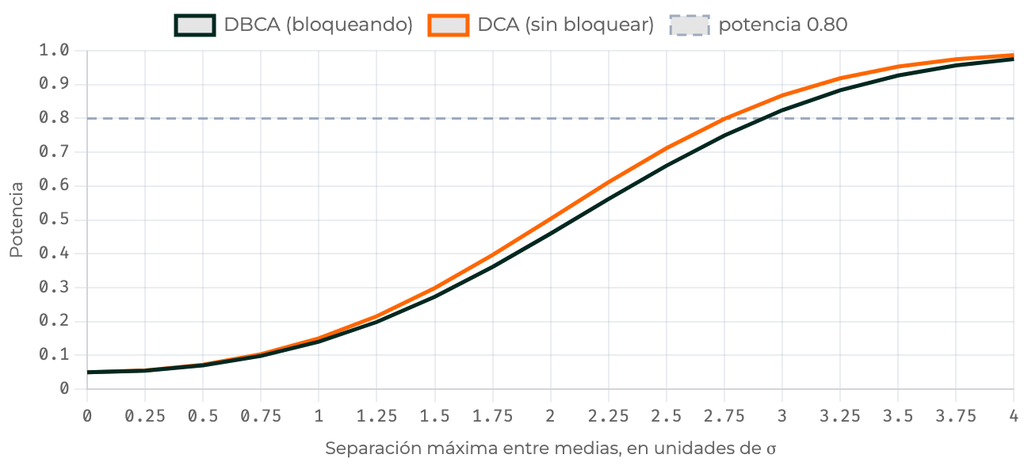

Potencia del DBCA y del DCA cuando el efecto de bloque no existe, frente a la separación entre medias

Capítulo 5 · Diseños en bloques completos al azarDiseño de Experimentos · UnBosque9 / 37

Idea clave

## Ante la duda razonable, bloquea

Lo que se arriesga: hasta 7.6 puntos de potencia, y menos cuantos más bloques. Lo que se gana cuando el bloque existe: \(R\) entre 1.9 y 11.6 en los cinco conjuntos.

Capítulo 5 · Diseños en bloques completos al azarDiseño de Experimentos · UnBosque10 / 37

Pregunta para la clase

## Bloquear duplicó la precisión y no se detectó nada. ¿Falló el bloqueo?

El refinador de grano (problema 4.19): bloquear por horno dio \(R = 1.99\), y las velocidades de agitación salieron con \(F = 0.85\) y \(p = 0.4995\).

No: son dos preguntas distintas

La eficiencia relativa dice cuánto ruido se quitó, no si había señal debajo. Bloquear funcionó; no había nada que encontrar.

Capítulo 5 · Diseños en bloques completos al azarDiseño de Experimentos · UnBosque11 / 37

Universidad El Bosque

Diseño de Experimentos

Capítulo 5 · Diseños en bloques completos al azar

Eficiencia relativa

Comparaciones y número de bloques

Diagnóstico y no aditividad

Cuando falta un dato

El bloque como factor aleatorio

Ciencia de datos

Cierre y práctica

02

## Comparaciones y número de bloques

Casi todo está hecho: el capítulo 3 vale con una sola sustitución.

Leer en el material: 5.7 Estimación, comparaciones múltiples y cuántos bloques hacen falta

12 / 37

Comparaciones y número de bloques

## Todo el capítulo 3 sirve cambiando \(n\) por \(b\) y \(N-a\) por \((a-1)(b-1)\)

$$\text{EE}(\bar y_{i.}) = \sqrt{\frac{MS_E}{b}}, \qquad \text{EE}(\bar y_{i.} - \bar y_{k.}) = \sqrt{\frac{2\,MS_E}{b}}$$

En una diferencia, los efectos de bloque se cancelan **observación a observación**: la cancelación es exacta, y un DCA no puede prometerla.

Lo que no se traduce

Comparar los **bloques**. No se rechaza un lote de resina: si interesara comparar sus niveles, no era un bloque, era un segundo factor (capítulo 7).

Capítulo 5 · Diseños en bloques completos al azarDiseño de Experimentos · UnBosque13 / 37

Pregunta para la clase

## ¿Qué pares separan el LSD y Tukey en el injerto?

Diferencias entre las medias de presión, con \(\text{EE} = \sqrt{2 \cdot 7.326/6} = 1.563\):

|  | 8700 | 8900 | 9100 |
| --- | --- | --- | --- |
| 8500 | 1.133 | 3.900 | 7.050 |
| 8700 |  | 2.767 | 5.917 |
| 8900 |  |  | 3.150 |

Umbrales: **LSD 3.331**, **Tukey 4.504**.

Respuesta

Tukey separa **8500–9100** (7.05) y **8700–9100** (5.92). El LSD, más liberal, añade **8500–8900** (3.90).

Capítulo 5 · Diseños en bloques completos al azarDiseño de Experimentos · UnBosque14 / 37

Comparaciones y número de bloques

## Con seis lotes la potencia es 0.96; con tres, una moneda al aire

Potencia exacta con la F no central

```
potencia_dbca <- function(a, b, tau, sigma2, alpha = 0.05) {
  gl1 <- a - 1; gl2 <- (a - 1) * (b - 1)
  lambda <- b * sum(tau^2) / sigma2
  pf(qf(1 - alpha, gl1, gl2), gl1, gl2, ncp = lambda, lower.tail = FALSE)
}
round(sapply(2:8, function(b) potencia_dbca(4, b, tau_hat, ms_e)), 4)
#> [1] 0.2421 0.5492 0.7804 0.9068 0.9642 0.9873 0.9958
```

Es potencia retrospectiva

Los \(\hat\tau_i\) y el \(MS_E\) salen del mismo experimento. Para planificar se pone la diferencia que interesa **por razones técnicas**, no la que salió.

Capítulo 5 · Diseños en bloques completos al azarDiseño de Experimentos · UnBosque15 / 37

Comparaciones y número de bloques

## Para planificar, la diferencia se fija en unidades de \(\sigma\), antes de ver los datos

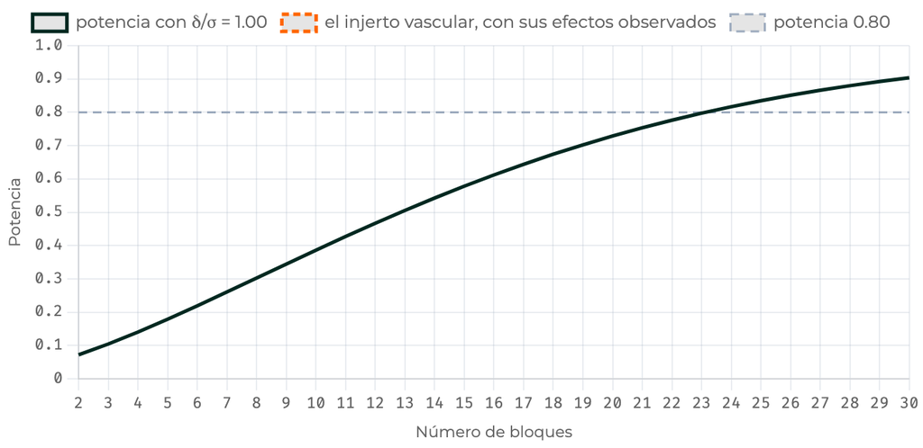

Potencia del DBCA frente al número de bloques, con la línea del 80 %

Capítulo 5 · Diseños en bloques completos al azarDiseño de Experimentos · UnBosque16 / 37

Universidad El Bosque

Diseño de Experimentos

Capítulo 5 · Diseños en bloques completos al azar

Eficiencia relativa

Comparaciones y número de bloques

Diagnóstico y no aditividad

Cuando falta un dato

El bloque como factor aleatorio

Ciencia de datos

Cierre y práctica

03

## Diagnóstico y no aditividad

El diagnóstico del capítulo 4 vale entero. Cambian dos cosas, y las dos importan.

Leer en el material: 5.8 Diagnóstico del modelo y la no aditividad de Tukey

17 / 37

Diagnóstico y no aditividad

## Hay un panel nuevo: los residuos contra el bloque

Desviación típica de los residuos del injerto, lote por lote:

| Lote 1 | Lote 2 | Lote 3 | Lote 4 | Lote 5 | Lote 6 |
| --- | --- | --- | --- | --- | --- |
| 1.98 | **3.43** | 2.88 | 2.45 | 2.54 | **0.44** |

Lo demás sale limpio: Shapiro con \(p = 0.369\), correlación del gráfico normal de 0.9828 y residuo estandarizado mayor de 1.54. El lote 6 es **llamativamente homogéneo**: no invalida nada, pero es lo que ese panel existe para enseñar.

Capítulo 5 · Diseños en bloques completos al azarDiseño de Experimentos · UnBosque18 / 37

Diagnóstico y no aditividad

## En un DBCA los residuos contra ajustados sí pueden curvarse

Qué significa la curvatura

**Interacción bloque × tratamiento**: el efecto del tratamiento depende del bloque. El modelo no tiene término para ella, así que se va al error, lo infla, y el \(F\) de tratamientos se vuelve conservador.

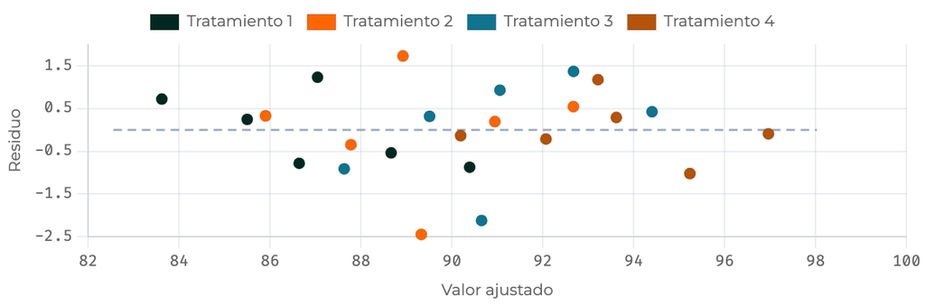

Residuos contra ajustados en el escenario aditivo del simulador

Capítulo 5 · Diseños en bloques completos al azarDiseño de Experimentos · UnBosque19 / 37

Diagnóstico y no aditividad

## La prueba de Tukey gasta un grado de libertad en la interacción más probable

$$y_{ij} = \mu + \tau_i + \beta_j + c\,\tau_i\beta_j + \varepsilon_{ij}$$

$$SS_N = \frac{\left[\sum_i\sum_j y_{ij}\,\hat\tau_i\hat\beta_j\right]^2}{\left(\sum_i \hat\tau_i^2\right)\left(\sum_j \hat\beta_j^2\right)}$$

$$F_0 = \frac{SS_N/1}{(SS_E - SS_N)/[(a-1)(b-1)-1]}$$

Un regresor, **un grado de libertad**: esa es toda la magia.

Capítulo 5 · Diseños en bloques completos al azarDiseño de Experimentos · UnBosque20 / 37

Diagnóstico y no aditividad

## En el injerto la aditividad aguanta: \(SS_N = 0.197\) de 109.886

La prueba de no aditividad, a mano

```
no_aditividad <- function(y, trt, blq) {
  A <- tapply(y, trt, mean) - mean(y)
  B <- tapply(y, blq, mean) - mean(y)
  num <- sum(y * A[as.integer(trt)] * B[as.integer(blq)])
  ss_n <- num^2 / (sum(A^2) * sum(B^2))
  tab <- anova(aov(y ~ trt + blq))
  gl_resto <- tab["Residuals", "Df"] - 1
  ss_resto <- tab["Residuals", "Sum Sq"] - ss_n
  F0 <- ss_n / (ss_resto / gl_resto)
  c(SS_N = ss_n, SS_resto = ss_resto, gl_resto = gl_resto, F0 = F0,
    p = pf(F0, 1, gl_resto, lower.tail = FALSE),
    c_estimado = num / (sum(A^2) * sum(B^2)))
}
round(no_aditividad(injerto$y, injerto$presion, injerto$lote), 6)
#>       SS_N   SS_resto   gl_resto         F0          p c_estimado
#>   0.196856 109.689394  14.000000   0.025125   0.876319  -0.011744
```

Capítulo 5 · Diseños en bloques completos al azarDiseño de Experimentos · UnBosque21 / 37

Pregunta para la clase

## EG-19: ¿interacción, o una sola observación que la finge?

Cinco boquillas a seis velocidades de chorro. La prueba de Tukey **rechaza** la aditividad (\(p = 0.031\)), y el residuo estandarizado mayor, **2.27**, es el 1.14 de la boquilla 4 a la velocidad más baja. ¿Qué haces?

Mirar antes de transformar

Si ese 1.14 se cambia por el 0.958 que predice el modelo aditivo, la no aditividad desaparece (\(p = 0.331\)) y el \(F\) de boquillas **sube** de 8.916 a 10.759. No se borra: se declara, y se reportan las dos lecturas.

Capítulo 5 · Diseños en bloques completos al azarDiseño de Experimentos · UnBosque22 / 37

Diagnóstico y no aditividad

## Si la aditividad se rompe: transformar, buscar el culpable o replicar

### Transformar

Una interacción multiplicativa es aditiva en logaritmos. En el simulador, \(p\) pasa de 0.0000 a 0.6639.

### Buscar el culpable

A veces la fabrica una sola observación, como en el EG-19. Se mira antes de transformar.

### Replicar

Con más de una observación por celda, la interacción se estima sin suponerle forma: factorial con bloques, capítulo 7.

Capítulo 5 · Diseños en bloques completos al azarDiseño de Experimentos · UnBosque23 / 37

Universidad El Bosque

Diseño de Experimentos

Capítulo 5 · Diseños en bloques completos al azar

Eficiencia relativa

Comparaciones y número de bloques

Diagnóstico y no aditividad

Cuando falta un dato

El bloque como factor aleatorio

Ciencia de datos

Cierre y práctica

04

## Cuando falta un dato

Se rompe una probeta, un paciente no vuelve. Con la celda vacía se rompe también la ortogonalidad.

Leer en el material: 5.9 Cuando falta un dato

24 / 37

Cuando falta un dato

## El valor clásico para la celda vacía es el vértice de la parábola \(SS_E(x)\)

$$x = \frac{a\,y'_{i.} + b\,y'_{.j} - y'_{..}}{(a-1)(b-1)}$$

Borrando el 94.7 del injerto (8700 psi, lote 4), la fórmula da **91.08**.

Se analiza con la celda rellena y se descuenta **un grado de libertad** del error.

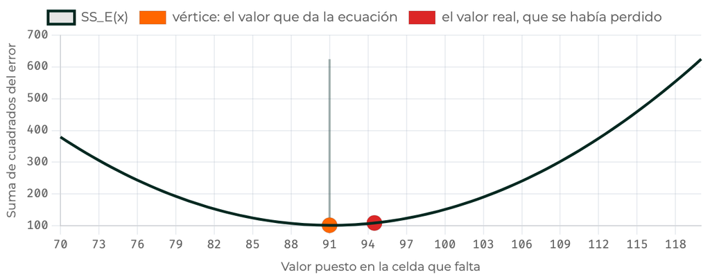

La suma de cuadrados del error frente al valor puesto en la celda que falta

Capítulo 5 · Diseños en bloques completos al azarDiseño de Experimentos · UnBosque25 / 37

Pregunta para la clase

## Faltando un dato, ¿por qué no coinciden las dos sumas de cuadrados de tratamientos?

| Análisis | \(SS_{\text{Trat}}\) | \(MS_E\) | gl | \(F_0\) |
| --- | --- | --- | --- | --- |
| Datos completos | 178.171 | 7.326 | 15 | 8.107 |
| Rellenando la celda | 166.144 | 7.264 | 14 | 7.624 |
| Exacto, sin rellenar | 163.398 | 7.264 | 14 | 7.498 |

Porque se perdió la ortogonalidad

Rellenar hace que el diseño *parezca* balanceado. El análisis exacto ajusta los tratamientos por los bloques: `lm(y ~ lote + presion)`, con los **bloques primero**.

Capítulo 5 · Diseños en bloques completos al azarDiseño de Experimentos · UnBosque26 / 37

Universidad El Bosque

Diseño de Experimentos

Capítulo 5 · Diseños en bloques completos al azar

Eficiencia relativa

Comparaciones y número de bloques

Diagnóstico y no aditividad

Cuando falta un dato

El bloque como factor aleatorio

Ciencia de datos

Cierre y práctica

05

## El bloque como factor aleatorio

Los seis lotes son una muestra de la producción de resina, no los únicos que interesan.

Leer en el material: 5.10 El bloque como factor aleatorio

27 / 37

El bloque como factor aleatorio

## Con lotes al azar, el bloque deja un solo parámetro: \(\sigma^2_\beta\)

$$\beta_j \sim \text{NID}(0, \sigma^2_\beta), \qquad \hat\sigma^2_\beta = \frac{MS_{\text{Bloques}} - MS_E}{a} = \frac{38.45 - 7.33}{4} = 7.78$$

El mismo componente por REML

```
library(nlme)
reml <- lme(y ~ presion, random = ~ 1 | lote, data = injerto,
            method = "REML")
round(as.numeric(VarCorr(reml)[, "Variance"]), 6)
#> [1] 7.781166 7.325750
```

El \(F\) de tratamientos y las comparaciones **no cambian**. La correlación intraclase, \(7.78/(7.78 + 7.33) = 0.515\), es la correlación entre dos observaciones del mismo lote.

Capítulo 5 · Diseños en bloques completos al azarDiseño de Experimentos · UnBosque28 / 37

El bloque como factor aleatorio

## Sin efecto de bloque, el estimador ANOVA sale negativo en el 55 % de los casos

$$P(\hat\sigma^2_\beta < 0) = P\!\left(F_{b-1,\,(a-1)(b-1)} < \frac{1}{1 + a\,\sigma^2_\beta/\sigma^2}\right)$$

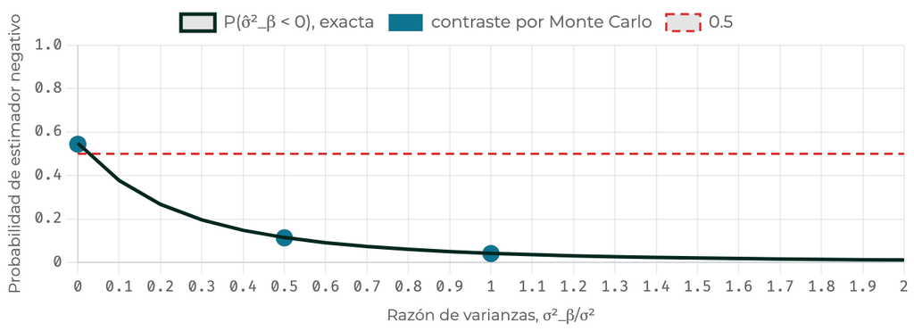

Cuando pase, se reporta \(\hat\sigma^2_\beta = 0\) y se dice que se truncó.

Capítulo 5 · Diseños en bloques completos al azarDiseño de Experimentos · UnBosque29 / 37

Universidad El Bosque

Diseño de Experimentos

Capítulo 5 · Diseños en bloques completos al azar

Eficiencia relativa

Comparaciones y número de bloques

Diagnóstico y no aditividad

Cuando falta un dato

El bloque como factor aleatorio

Ciencia de datos

Cierre y práctica

06

## Ciencia de datos

Si sabes de dónde viene una parte del ruido, sácala del error. El principio no es propiedad del laboratorio.

Leer en el material: 5.11 Ciencia de datos: bloquear, estratificar y no filtrar información

30 / 37

Ciencia de datos

## El correo directo es un test A/B/C por bloques: el error cae dos veces y media

Tres folletos enviados en cuatro regiones, contando las respuestas. Es el ejemplo de eficiencia relativa del módulo 5.6, y la región es el bloque.

| Análisis | Folleto 2 − folleto 1 | Error estándar | \(p\) de los folletos |
| --- | --- | --- | --- |
| Sin la región | 175.25 | 55.01 | 0.012 |
| Con la región | 175.25 | **21.27** | **0.00018** |

La diferencia es **la misma**, porque el diseño está balanceado; lo que se encoge es su error. En la jerga de los tests A/B, eso es *reducción de varianza*.

Capítulo 5 · Diseños en bloques completos al azarDiseño de Experimentos · UnBosque31 / 37

Ciencia de datos

## El bloque tiene otros cuatro nombres

### Muestreo estratificado

Se muestrea dentro de estratos homogéneos. El estrato es el bloque, y la ganancia de precisión se calcula igual.

### Test A/B por bloques

En vez de una moneda por usuario, las variantes se reparten dentro de cada segmento: país, plataforma, cohorte.

### Emparejamiento causal

Comparar cada tratado con un control parecido es bloquear *a posteriori*, con los datos ya recogidos.

### Validación por grupos

El caso menos obvio: varias filas por paciente, por lote o por usuario. Es la pregunta siguiente.

Capítulo 5 · Diseños en bloques completos al azarDiseño de Experimentos · UnBosque32 / 37

Pregunta para la clase

## Un modelo que ve el lote, validado al azar, ¿qué error promete?

25 lotes de 12 unidades con ICC = 0.75. El error real frente a un lote nuevo ronda **2.05**.

| RMSE | Ve el lote | No lo ve |
| --- | --- | --- |
| Partición aleatoria | **?** | 1.99 |
| Partición por lote | 2.05 | 2.05 |

1.09: el doble de precisión de la que tendrá

Vio en entrenamiento once observaciones del mismo lote que predice. La razón teórica es \(1/\sqrt{1 - \text{ICC}} = 2\).

Capítulo 5 · Diseños en bloques completos al azarDiseño de Experimentos · UnBosque33 / 37

Idea clave

## Si sabes de dónde viene el agrupamiento, respétalo al partir

En el experimento, el bloque saca ruido del error; en la validación, impide meter información donde no debe estar. Las dos veces la pregunta es la misma: ¿qué tienen en común dos observaciones que no comparten con las demás?

Capítulo 5 · Diseños en bloques completos al azarDiseño de Experimentos · UnBosque34 / 37

Universidad El Bosque

Diseño de Experimentos

Capítulo 5 · Diseños en bloques completos al azar

Eficiencia relativa

Comparaciones y número de bloques

Diagnóstico y no aditividad

Cuando falta un dato

El bloque como factor aleatorio

Ciencia de datos

Cierre y práctica

07

## Cierre y práctica

Leer en el material: 5.12 Resumen, autoevaluación y lecturas

35 / 37

Cierre y práctica

## Lo que se llevan hoy

- \(R\) dice cuántas réplicas necesitaría un DCA; bloquear en balde cuesta poco
- El capítulo 3 vale con \(b\) en el lugar de \(n\); los bloques no se comparan
- La curvatura en residuos contra ajustados es interacción, y la mide la prueba de Tukey
- Si falta un dato, los **bloques primero**; si son una muestra, se estima \(\sigma^2_\beta\)
- Con datos agrupados, el modelo se valida partiendo por grupo

Javier Mauricio Sierra

Capítulo 5 · Diseños en bloques completos al azarDiseño de Experimentos · UnBosque36 / 37

Cierre y práctica

## Práctica en R: los ejercicios guiados que quedan

### EG-17 (d)

Se pierde el agente 2 en el rollo 3: estímalo y compara el análisis aproximado con el exacto.

### EG-18

Tres aceites y cinco camiones de la flota: estima \(\sigma^2_\beta\) y la fracción que explica.

### EG-20

El bloque es una persona: eficiencia relativa y contraste lineal con \((-3, -1, 1, 3)\).

Capítulo 5 · Diseños en bloques completos al azarDiseño de Experimentos · UnBosque37 / 37

### Atajos del teclado

[output not shown]

·

00:00

A continuación

Notas